```r
library(gapminder)
library(tidyverse)
library(car)
library(dplyr)
library(e1071)
```

1. Assess normality of Life Expectancy in the Americas in the year 2007. Include all appropriate plots and outcomes, and explain your decision of whether it is normal or not. [3 marks]

```r
# Loading data and subsetting
df <- gapminder %>%
  filter (year == 2007)
df1<-df$lifeExp
length(df1)
```

```
## [1] 142
```

```r
dfg1 <- data.frame(value=df1,
                   ID=seq(1,142,by=1))
```

Plot the histogram

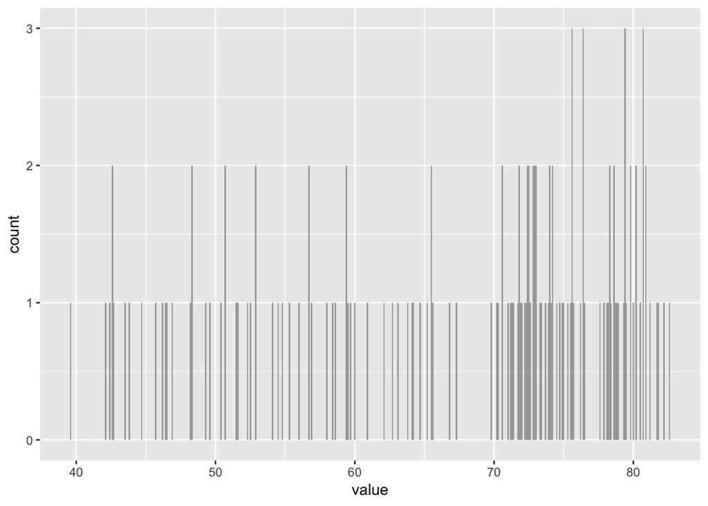

```r
ggplot(dat=dfg1, aes(x=value))+
  geom_histogram(binwidth=0.1, alpha=0.5, position="identity")
```

Check normality using qq plot

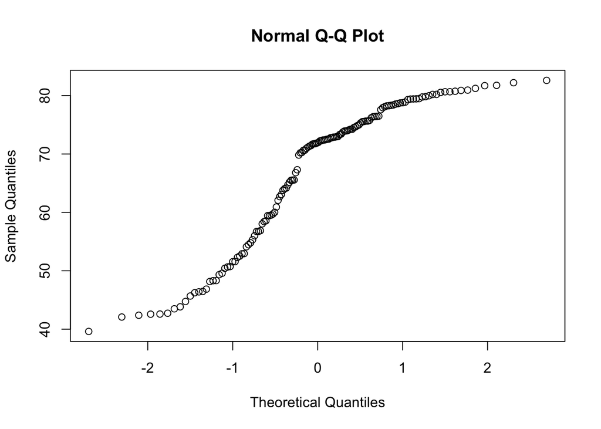

```r
qqnorm(df1)
```

Check skewness

```r
print(skewness(df1))
```

```
## [1] -0.6742938
```

```r
shapiro.test(x = df1)
```

```
##
##  Shapiro-Wilk normality test
##
## data:  df1
## W = 0.89467, p-value = 1.357e-08
```

```r
ks.test(x = df1,
        y = "pnorm",
        mean = mean(df1),
        sd = sd(df1))
```

```
##
##  One-sample Kolmogorov-Smirnov test
##
## data:  df1
## D = 0.18872, p-value = 8.094e-05
## alternative hypothesis: two-sided
```

2. Are there ‘population’ outliers when comparing Asian countries to European countries in 1952? What are the different options to handle outliers, and what do you think is the best option to handle outliers when making this comparison? [3 marks]

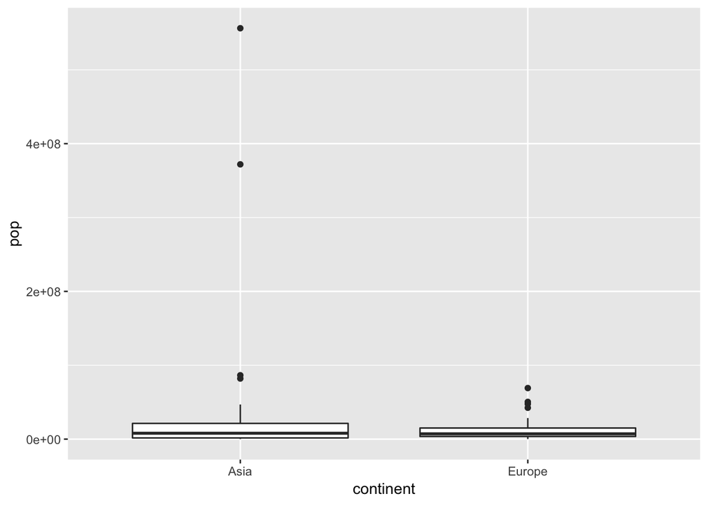

```r
df <- gapminder %>%
  filter (year == 1952 & (continent == "Asia" | continent == "Europe") )

library(ggplot2)
ggplot(df , aes(x=continent, y=pop)) +
  geom_boxplot()
```

This plot shows that the outlier exist in both group. The optins to deal with outliers: 1. Remove them: This should ONLY be used when you are sure the data point is not a measured value • E.g., Heart rate data above 250 bpm; not plausible 2. Transform the data • E.g., log/power/inverse 3. Change the score: This may seem like cheating, but if your data point is going to bias your data anyways, this is better than leaving it in • E.g., The next highest score + 1 • E.g., Change it to 3SD above the mean; make it physiological 4. Use non-parametrics

For this case, transform the data will be an good choice.

For the following questions, if your data breaks assumptions, you must attempt to correct it using a data transformation. If no normality transformations help, proceed as if the assumptions are intact and state this in your response.

2. Life Expectancy: Conduct the appropriate statistical test, demonstrate the underlying assumptions, plot the results, and briefly report the results in a ‘publishable’ format, to answer a research question of your choice phrased in the following format: [5 marks]

Is life expectancy greater in [continent] compared to [continent] in [year]?

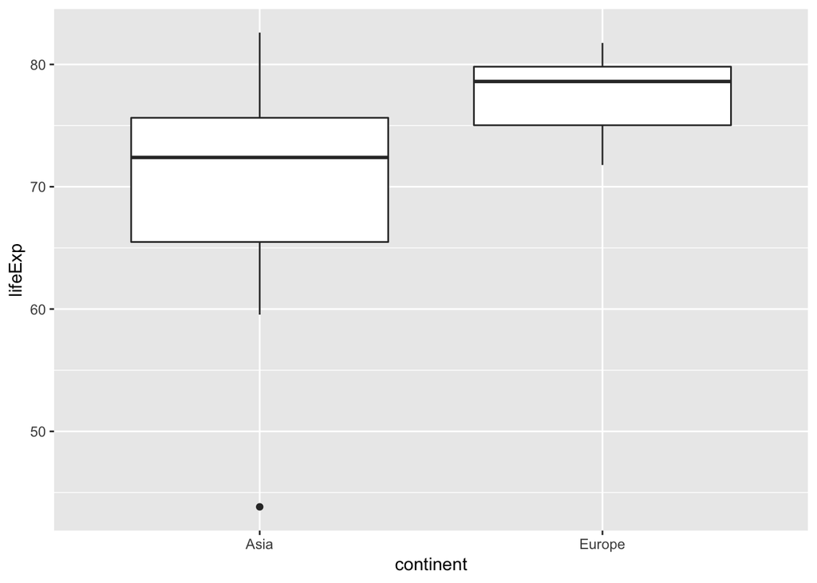

```r
# Subsetting
df <- gapminder %>%
  filter (year == 2007 & (continent == "Asia" | continent == "Europe") )

dfa <- gapminder %>%
  filter (year == 2007 & continent == "Asia")

dfe <- gapminder %>%
  filter (year == 2007 & continent == "Europe")


library(ggplot2)
ggplot(df , aes(x=continent, y=lifeExp)) +
  geom_boxplot()
```

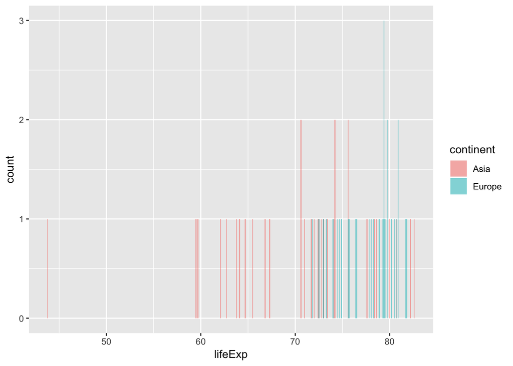

```r
# Visualize the subset distribution by Histogram Plot

ggplot(df, aes(x=lifeExp, fill=continent)) +
  geom_histogram(binwidth=0.1, alpha=0.5, position="identity")
```

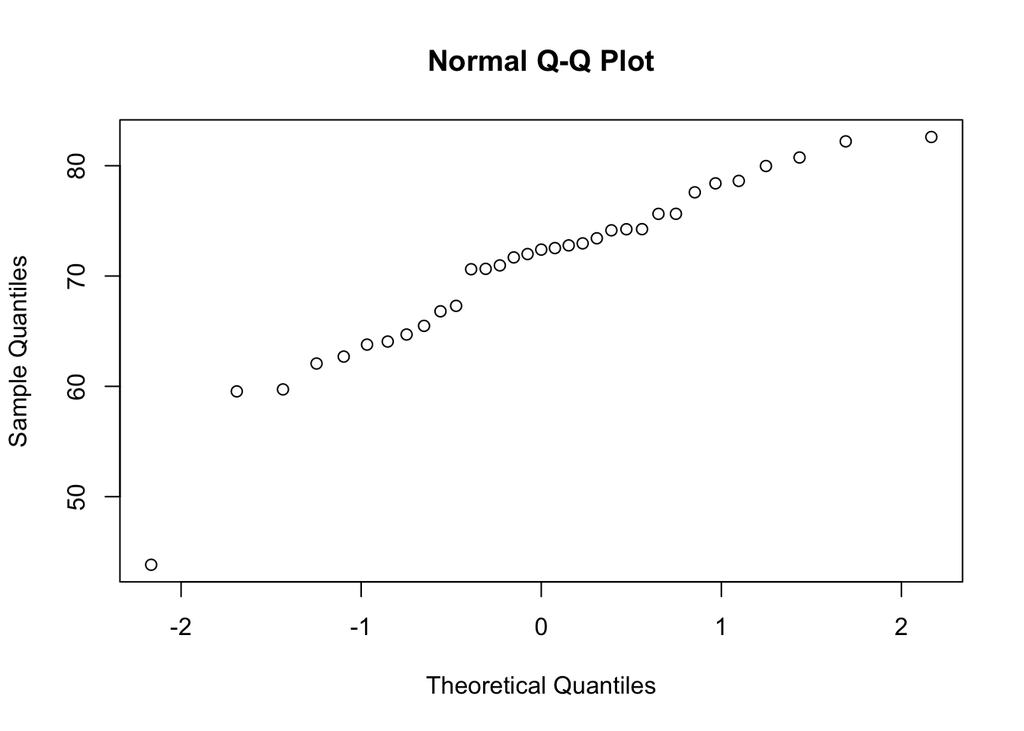

```r
# visualizing normality by q-q plot of the subset life expectancy in Asia at 2007
qqnorm(dfa$lifeExp)
```

```r
# Check the skewness of the subset life expectancy in Asia at 2007
print(skewness(dfa$lifeExp))
```

```
## [1] -1.067752
```

```r
# Shapiro-Wilk normality test of the subset life expectancy in Asia at 2007
shapiro.test(x = dfa$lifeExp)
```

```
##
##  Shapiro-Wilk normality test
##
## data:  dfa$lifeExp
## W = 0.92228, p-value = 0.02119
```

```r
# One-sample Kolmogorov-Smirnov test of the subset life expectancy in Asia at 2007

ks.test(x = dfa$lifeExp,
        y = "pnorm",
        mean = mean(dfa$lifeExp),
        sd = sd(dfa$lifeExp))
```

```
##
##  One-sample Kolmogorov-Smirnov test
##
## data:  dfa$lifeExp
## D = 0.16103, p-value = 0.3236
## alternative hypothesis: two-sided
```

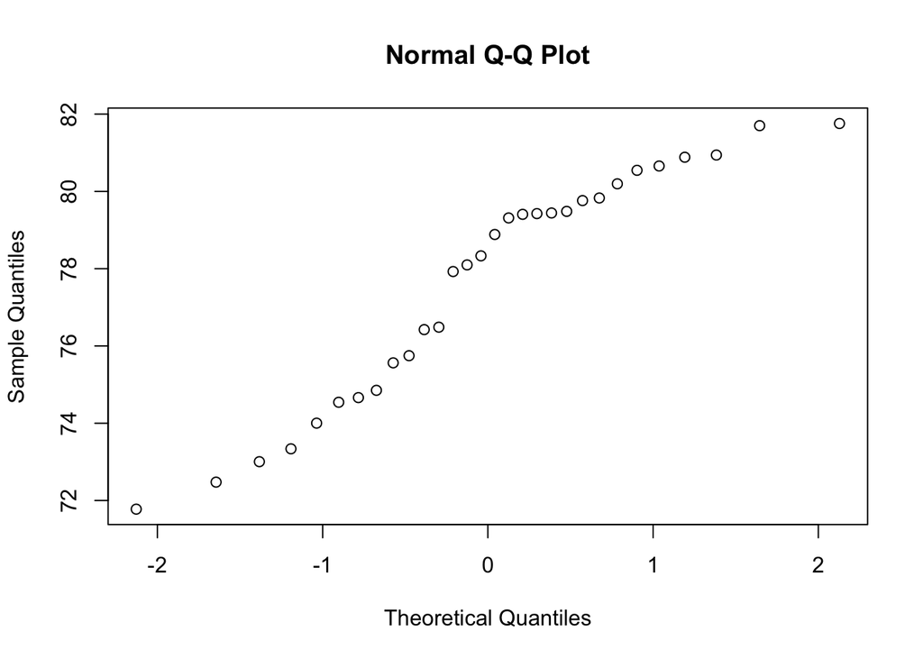

```r
# visualizing normality by q-q plot of the subset life expectancy in Europe at 2007
qqnorm(dfe$lifeExp)
```

```r
# Check the skewness of the subset life expectancy in Europe at 2007
print(skewness(dfe$lifeExp))
```

```
## [1] -0.433502
```

```r
# Shapiro-Wilk normality test of the subset life expectancy in Europe at 2007
shapiro.test(x = dfe$lifeExp)
```

```
##
##  Shapiro-Wilk normality test
##
## data:  dfe$lifeExp
## W = 0.92333, p-value = 0.03274
```

```r
# One-sample Kolmogorov-Smirnov test of the subset life expectancy in Europe at 2007

ks.test(x = dfe$lifeExp,
        y = "pnorm",
        mean = mean(dfe$lifeExp),
        sd = sd(dfe$lifeExp))
```

```
##
##  One-sample Kolmogorov-Smirnov test
##
## data:  dfe$lifeExp
## D = 0.17844, p-value = 0.2623
## alternative hypothesis: two-sided
```

Shapiro-Wilk normality test results show that both the dataset of life expectancy in Europe and Asia in 2007 are non-normal. So the data will be log-transformed.

```r
# Fix the outcome with a log transform
dft <- df %>%
  mutate(value_log = log(lifeExp))
dfat <- dft %>%
  filter (year == 2007 & continent == "Asia")
dfet <- dft %>%
  filter (year == 2007 & continent == "Europe")
```

Run normality check again on the subset life expectancy in Asia at 2007

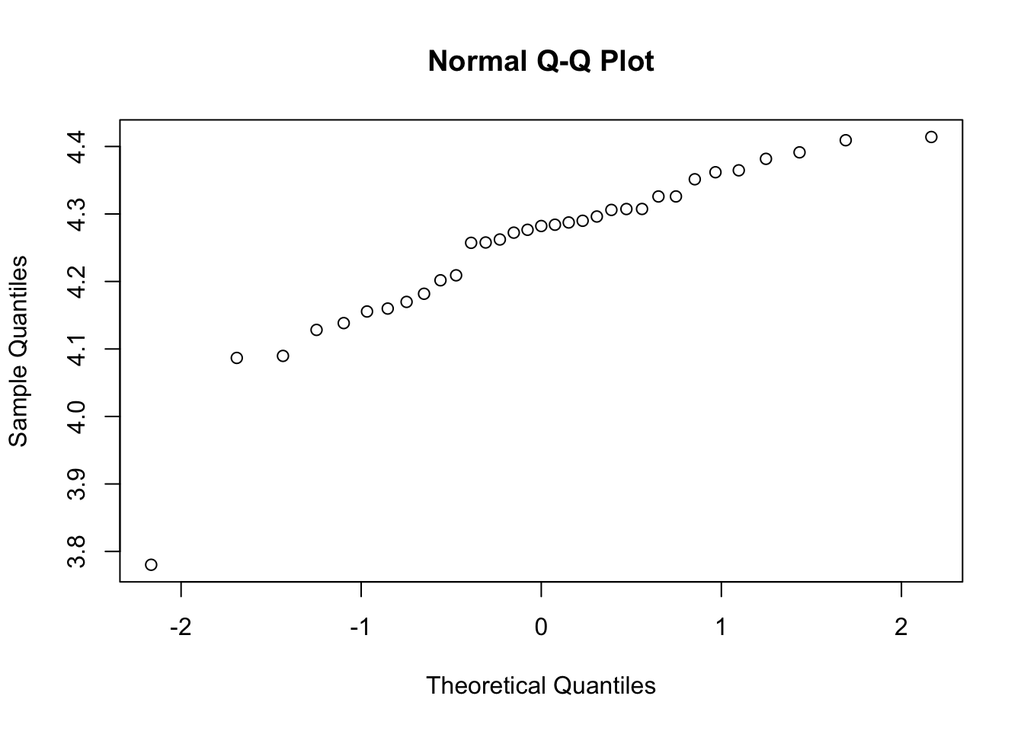

```r
qqnorm(dfat$value_log)
```

```r
print(skewness(dfat$value_log))
```

```
## [1] -1.63341
```

```r
shapiro.test(x = dfat$value_log)
```

```
##
##  Shapiro-Wilk normality test
##
## data:  dfat$value_log
## W = 0.8617, p-value = 0.0006227
```

```r
ks.test(x = dfat$value_log,
        y = "pnorm",
        mean = mean(dfat$value_log),
        sd = sd(dfat$value_log))
```

```
##
##  One-sample Kolmogorov-Smirnov test
##
## data:  dfat$value_log
## D = 0.18387, p-value = 0.1894
## alternative hypothesis: two-sided
```

Run normality again on the subset life expectancy in Europe at 2007

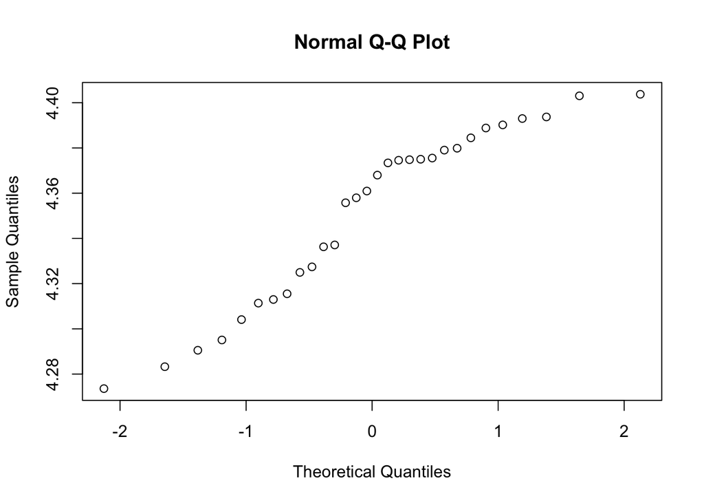

```r
qqnorm(dfet$value_log)
```

```r
print(skewness(dfet$value_log))
```

```
## [1] -0.4719991
```

```r
shapiro.test(x = dfet$value_log)
```

```
##
##  Shapiro-Wilk normality test
##
## data:  dfet$value_log
## W = 0.91986, p-value = 0.02659
```

```r
ks.test(x = dfet$value_log,
        y = "pnorm",
        mean = mean(dfet$value_log),
        sd = sd(dfet$value_log))
```

```
##
##  One-sample Kolmogorov-Smirnov test
##
## data:  dfet$value_log
## D = 0.18096, p-value = 0.248
## alternative hypothesis: two-sided
```

After log-transform the subsets, neither subset is normal.

```r
#Check homogeneity of variance using Levene's Test
leveneTest(lifeExp~continent, data = dft, center = mean)
```

```
## Levene's Test for Homogeneity of Variance (center = mean)
##       Df F value   Pr(>F)
## group  1  11.805 0.001069 **
##       61
## ---
## Signif. codes:  0 '***' 0.001 '**' 0.01 '*' 0.05 '.' 0.1 ' ' 1
```

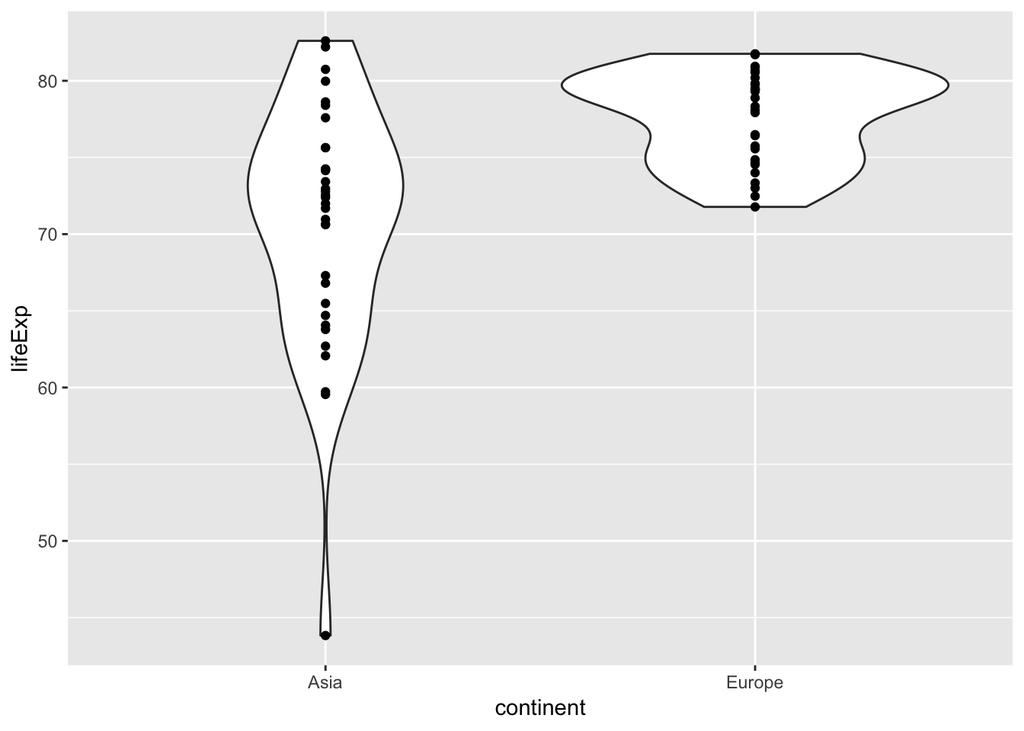

```r
ggplot(dat = dft, aes(x = continent, y = lifeExp))+
  geom_violin()+
  geom_point()
```

```r
# Independent T-test
t.test(x = dfat$value_log,
       y = dfet$value_log,
       alternative = "two.sided",
       var.equal = FALSE,
       paired = FALSE)
```

```
##
##  Welch Two Sample t-test
##
## data:  dfat$value_log and dfet$value_log
## t = -4.399, df = 38.806, p-value = 8.225e-05
## alternative hypothesis: true difference in means is not equal to 0
## 95 percent confidence interval:
##  -0.14531981 -0.05376503
## sample estimates:
## mean of x mean of y
##  4.251930  4.351473
```

3. Wealth: Conduct the appropriate statistical test, demonstrate the underlying assumptions, plot the results, and briefly report the results in a ‘publishable’ format, to answer a research question of your choice phased in the following format: [5 marks] Does GDP (gdpPercap) increase between [2002] and [2007] in [Europe]?

```r
# Subsetting
dfw <- gapminder %>%
  filter (continent == "Europe" & (year == 2002 | year == 2007 ) )
df2 <- gapminder %>%
  filter (year == 2002 & continent == "Europe")
df7 <- gapminder %>%
  filter (year == 2007 & continent == "Europe")

# log transform
dfwt <- dfw %>%
  mutate(value_log = log(gdpPercap))
df2t <- dfwt %>%
  filter (year == 2002 & continent == "Europe")
```

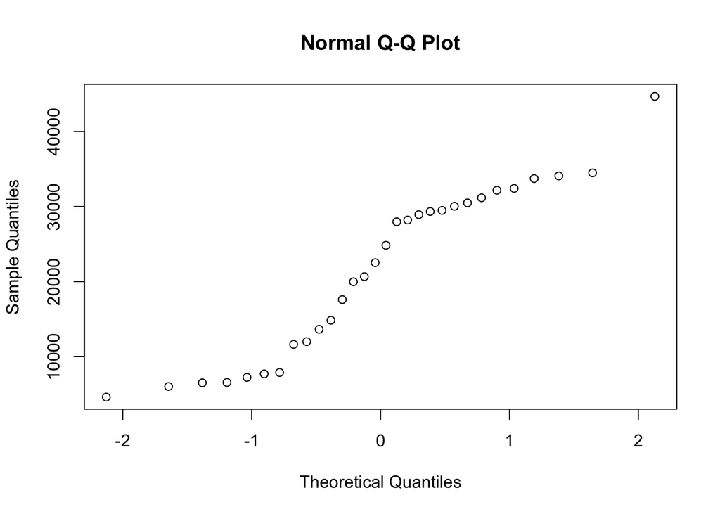

```r
# Check normality of GDP in Europe at 2002
qqnorm(df2$gdpPercap)
```

```r
print(skewness(df2$gdpPercap))
```

```
## [1] -0.07190613
```

```r
shapiro.test(x = df2$gdpPercap)
```

```
##
##  Shapiro-Wilk normality test
##
## data:  df2$gdpPercap
## W = 0.92042, p-value = 0.0275
```

```r
ks.test(x = df2$gdpPercap,
        y = "pnorm",
        mean = mean(df2$gdpPercap),
        sd = sd(df2$gdpPercap))
```

```
##
##  One-sample Kolmogorov-Smirnov test
##
## data:  df2$gdpPercap
## D = 0.1785, p-value = 0.262
## alternative hypothesis: two-sided
```

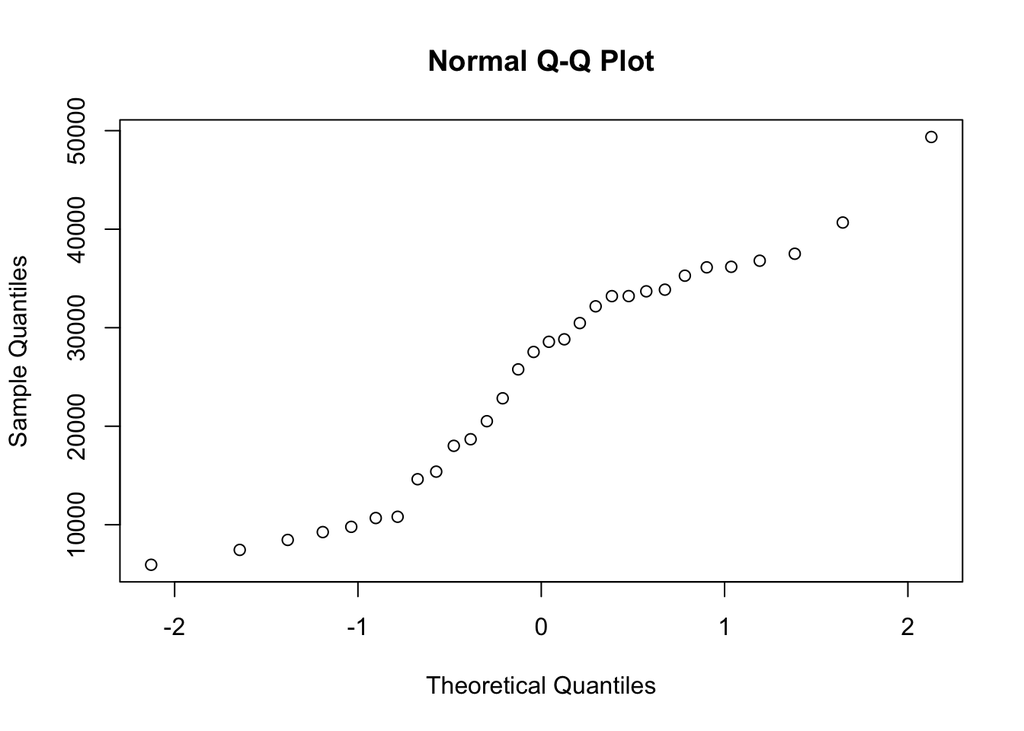

```r
# Check normality of GDP in Europe at 2007
qqnorm(df7$gdpPercap)
```

```r
print(skewness(df7$gdpPercap))
```

```
## [1] -0.09278249
```

```r
shapiro.test(x = df7$gdpPercap)
```

```
##
##  Shapiro-Wilk normality test
##
## data:  df7$gdpPercap
## W = 0.9395, p-value = 0.08816
```

```r
ks.test(x = df7$gdpPercap,
        y = "pnorm",
        mean = mean(df7$gdpPercap),
        sd = sd(df7$gdpPercap))
```

```
##
##  One-sample Kolmogorov-Smirnov test
##
## data:  df7$gdpPercap
## D = 0.12675, p-value = 0.6742
## alternative hypothesis: two-sided
```

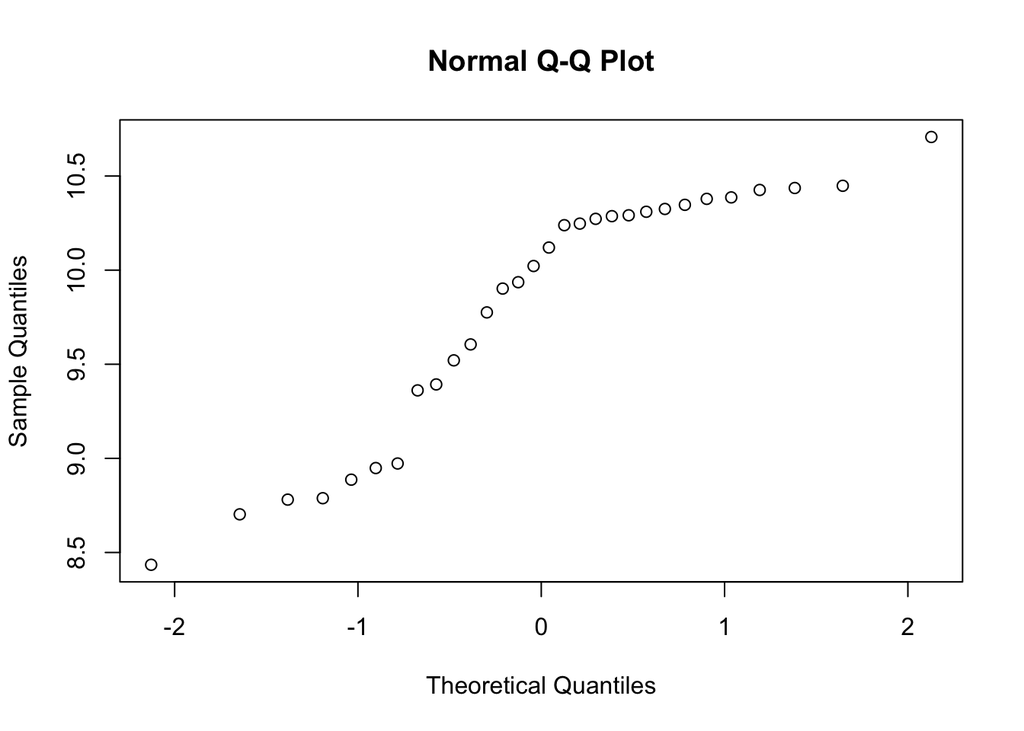

```r
# Check normalization again after dataset of GDP in Europe at 2002 is log-transformed
qqnorm(df2t$value_log)
```

```r
print(skewness(df2t$value_log))
```

```
## [1] -0.6328508
```

```r
shapiro.test(x = df2t$value_log)
```

```
##
##  Shapiro-Wilk normality test
##
## data:  df2t$value_log
## W = 0.87588, p-value = 0.002271
```

```r
ks.test(x = df2t$value_log,
        y = "pnorm",
        mean = mean(df2t$value_log),
        sd = sd(df2t$value_log))
```

```
##
##  One-sample Kolmogorov-Smirnov test
##
## data:  df2t$value_log
## D = 0.20916, p-value = 0.1251
## alternative hypothesis: two-sided
```

```r
# Dependent T-test
t.test(x = df2$gdpPercap,
       y = df7$gdpPercap,
       alternative = "two.sided",
       paired = TRUE)
```

```
##
##  Paired t-test
##
## data:  df2$gdpPercap and df7$gdpPercap
## t = -12.335, df = 29, p-value = 4.627e-13
## alternative hypothesis: true difference in means is not equal to 0
## 95 percent confidence interval:
##  -3896.994 -2788.505
## sample estimates:
## mean of the differences
##               -3342.749
```

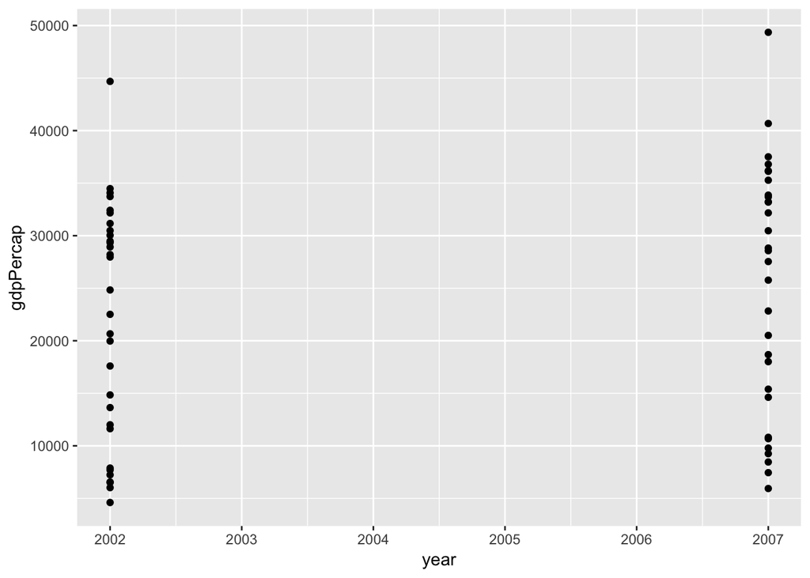

```r
ggplot(dat = dfw, aes(x = year, y = gdpPercap))+
  geom_point()
```

Subject characteristics are presented as above. GDP in Europe at 2002 (p = 0.0275) was found to be significantly non-normal, and were log-transformed. Using the log-transformed data, GDP in Europe at 2002 is still non-normal (p=0.002271), the dependent t-test result shows that GDP in Europe from at 2007 is hight that that in 2002 (p=4.627e-13).